# The definition, calculation and modeling of the pair distribution function (PDF)

What is PDF? How to calculate PDF? How to obtain structure parameters from PDF?

## What is the diffraction like in near field (continue with Sandra's picture in the last lecture)?

- A simulation of electric field from slits diffraction
  - Slits are on the left side wall and the wave is propagating from left to right.
  - wavelength = $\lambda$
  - slit distance = 2$\lambda$
  - picture width = 30$\lambda$

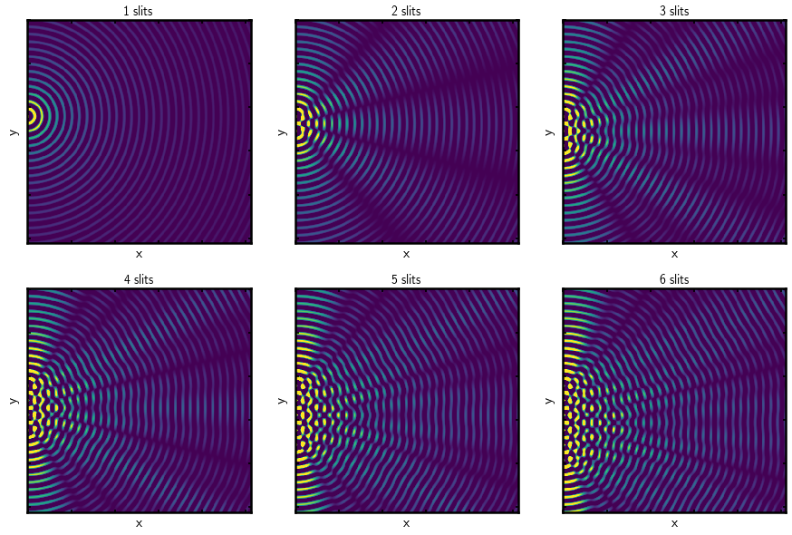

## Which picture is correct?

- Sandra's picture
  - each slit emits a spherical wave
  - spherical waves interact with each other
  - used in near field
- Bragg's picture
  - each slit emits a spherical wave
  - each spherical wave is approximated by a plane wave in the far field
  - plain waves interact with each other
  - used in far field

We use Bragg's picture because our detector is far away from the slits (atoms).

## Why can we use Fourier transformation to get PDF?

$$ E_{out} = \sum_i e^{- i \boldsymbol{k} \cdot (\boldsymbol{r} - \boldsymbol{r_i})}\\ = e^{- i \boldsymbol{k} \cdot \boldsymbol{r}} \sum_i e^{i \boldsymbol{k} \cdot \boldsymbol{r_i}}\\ = e^{- i \boldsymbol{k} \cdot \boldsymbol{r}} \mathscr{F} (\sum_i \delta(\boldsymbol{r} - \boldsymbol{r_i})) \\ = e^{- i \boldsymbol{k} \cdot \boldsymbol{r}} \mathscr{F}(T(\boldsymbol{r})) $$

output electric field = $\mathscr{F}$(the window function) * plane wave field

In x-ray diffraction, the window function is atom density $T(\boldsymbol{r}) = \rho(\boldsymbol{r})$.

## Why can we use Fourier transformation to get PDF?

$$ I_{out} = E_{out} E^*_{out}\\ = \mathscr{F}(\rho(\boldsymbol{r})) \mathscr{F}^{*}(\rho(\boldsymbol{r}))\\ = \mathscr{F}(\rho(\boldsymbol{r})) \mathscr{F}(\rho(-\boldsymbol{r}))\\ = \mathscr{F}(\rho(\boldsymbol{r}) * \rho(-\boldsymbol{r}))\\ = \mathscr{F}(P(\boldsymbol{u})) $$

output light intensity field = $\mathscr{F}$(the Patterson function)

## Why can we use Fourier transformation to get PDF?

$$ P(\boldsymbol{u}) = \rho(\boldsymbol{r}) * \rho(-\boldsymbol{r})\\ = \sum_i \delta(\boldsymbol{r} - \boldsymbol{R_i}) * \sum_j \delta(- \boldsymbol{r} - \boldsymbol{R_j})\\ = \sum_i \sum_j \delta(\boldsymbol{r} - (\boldsymbol{R_i} - \boldsymbol{R_j}))\\ = \sum_i \sum_j \delta(\boldsymbol{r} - \boldsymbol{r}_{ij}) $$

Patterson function = the distribution function of atomic pair distances

## How to learn the concept of a physics quantity?

1. Name of the quantity: e. g. velocity.
2. Meaning of the quantity: e. g. how fast an object is moving.
3. Definition of the quantity: e. g. velocity = displacement / time interval.
4. Determination of the quantity: e.g. velocity is determined by equation of motion.
5. Calculate the quantity in an example:

   e. g. the train A has velocity = 100 km / h, the train B has velocity = 200 km / h, which train is faster?

   e. g. a train departed station A at 8:00 am and arrived the station B 100 km away from A at 9:00 am, what is the (average) velocity of the train?.

   e. g. the position of the train follows x = 100 t where t is the time in hour, what is the velocity of the train?

## The definition of R(r)

Radial distribution function: how many pairs of atoms are there at distance $r$ in a unit volume.

$$\large R(r) = \frac{1}{N} \sum_{u} \sum_{v} \frac{f_u f_v}{\bar{f}^2} \delta(r - r_{uv})$$

The integral is the number of atoms in the structure.

$$\large \int_{0}^{\infty} R(r) dr = N$$

## Definition of the form factor

The scattering power (form factor or scattering length) is the strength of scattering from the individual atom.

|  | x-ray scattering | neutron scattering | electron scattering |
| --- | --- | --- | --- |
| Beam | x-ray | neutron beam | electron beam |
| Scatters | inner shell electrons | nucleus | Coulomb potential |
| Strength | atomic number | nuclear isotope and spin | Coulomb force |

## The definition of G(r)

Pair distribution function: how different is the density of atomic pairs at distance $r$ from the average.

$$\large G(r) = \frac{R(r)}{r} - 4{\pi}\rho_0r \text{, in 3D space}$$$$\large G(r) = \frac{R(r)}{r} - 2{\pi}\rho_0 \text{, in 2D space}$$$$\large G(r) = \frac{R(r)}{r} - \frac{2\rho_0}{r} \text{, in 1D space}$$

The integral is zero.

$$\large \int_{0}^{\infty} G(r) r dr = 0$$

## An example: 2D square crystal

In a two dimensional universe, the fundamental particle is an atom called "tao zi"(Chinese: 陶子). The "tao zi" has scattering power = 1 unit and bond length = 1 unit.

We have an infinite large two dimensional "tao zi" crystal an example.

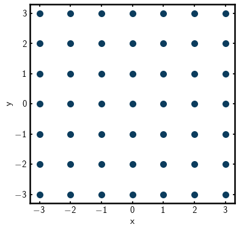

## Counting pairs

Every atom is equivalent so we just need to choose one atom as the origin and count the neigbours.

Every atom has the same scattering factor so the weights are 1.

$$ \large R(r) = \frac{1}{N} \sum_{u} \sum_{v} \frac{f_u f_v}{\bar{f}^2} \delta(r - r_{uv}) = \sum_{v} \delta(r - r_{0v}) $$

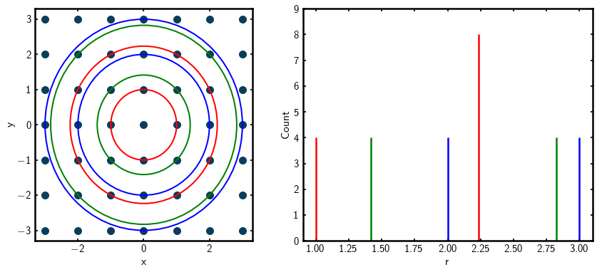

## Uncertainty in positions

The atoms randomly deviate from the lattice sites and the deviation follows normal distribution. The peaks change from delta functions to Gaussian functions.

$$\large R(r) = \sum_{v} \frac{1}{\sigma\sqrt{2\pi}} \exp(-\frac{(r - r_{0v})^2}{2\sigma^2})$$

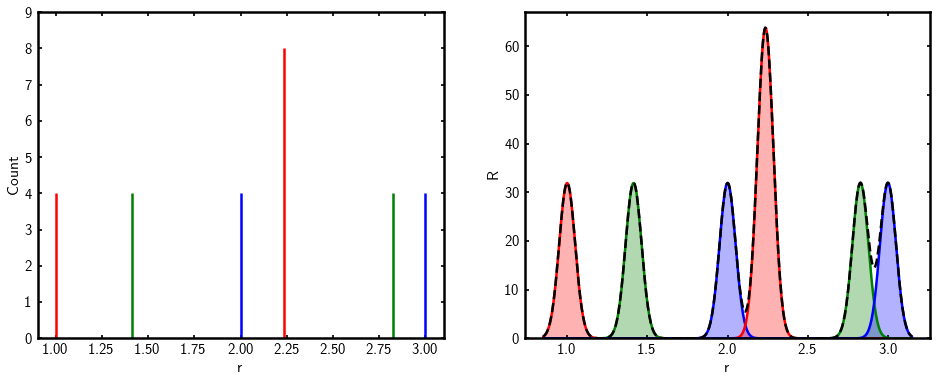

## R(r) and G(r) of a square crystal

$$\large G(r) = \frac{R(r)}{r} - 2{\pi}\rho_0$$

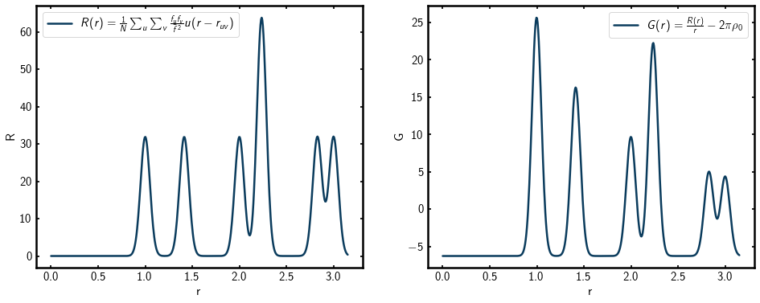

## Baselines of R(r) and G(r) in 2D space

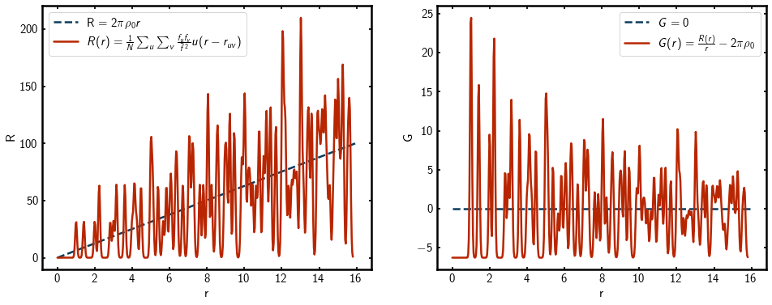

## Modeling of G(r): cost function

Optimization Problem:

$$\underset{p_0, p_1, ... , p_n}{\mathrm{argmin}} \frac{1}{2} \chi^2(p_0, p_1, ... , p_n)$$

Calculate cost function from residuals:

$$\chi^2(p_0, p_1, ... , p_n) = \int_0^{\infty} \left[ \frac{G_{obs}(r) - G_{cal}(r, p_0, p_1, ... , p_n)}{\Delta G_{obs}(r)} \right] ^2 dr$$

The $G_{cal}(r)$ is determined by structure models:

$$G_{cal}(r, p_0, p_1, ... , p_n) = F(Structure(p_0, p_1, ... , p_n))$$

## Modeling of G(r): visualize $\chi^2$

Usually, we don't know $\Delta G_{obs}(r)$ so we assume $\Delta G_{obs}(r) = 1$. Usually, the residuals oscillate around zero. The $\chi^2$ is manifested by the amplitude of oscillation.

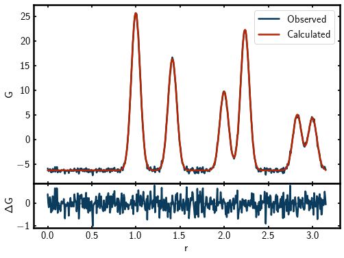

## Modeling of G(r): small box

A small box model is one lattice or one small super lattice. It is usually constrained by the symmetry. Only a few atoms need to be considered.

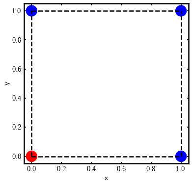

## Modeling of G(r): small box + gradient descent

We use gradient descent to solve the optimization problem.

[figure not shown]

## Modeling of G(r): small box + gradient descent

[figure not shown]

## Modeling of G(r): big box

A big box is a super lattice with many atoms. There usually are additional constrains of the atomic positions.

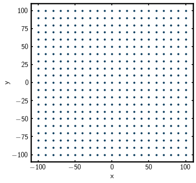

## Modeling of G(r): big box + reverse monte carlo

We use the reverse monte carlo to solve the optimization problem.

[figure not shown]

## Modeling of G(r): big box + reverse monte carlo

[figure not shown]

## Discussion

What are the forms of R(r) and G(r) in 4D Euclidean space? What are the baselines like?

What if the space has curvature? For example, when you are doing PDF measurement near a black hole, what equations will you use to calculate PDF?

Why do we use G(r) in our researches instead of R(r) which has a well-defined physics meaning?